# Task I

```python
import pandas as pd
import seaborn as sns

from google.colab import drive
drive.mount('/content/drive')
```

# Task II

```python
df = pd.read_csv("https://raw.githubusercontent.com/matthewpecsok/4482_fall_2022/main/data/carAuction.csv")
```

```python
df.describe()
```

|  | MMRCurrentAuctionAveragePrice | VehBCost | VehicleAge | VehOdo | WarrantyCost |
| --- | --- | --- | --- | --- | --- |
| count | 10000.000000 | 10000.000000 | 10000.000000 | 10000.000000 | 10000.000000 |
| mean | 6116.216000 | 6720.207200 | 4.182900 | 71541.084100 | 1279.954000 |
| std | 2426.340132 | 1753.796382 | 1.714509 | 14688.317704 | 609.026443 |
| min | 0.000000 | 225.000000 | 1.000000 | 4825.000000 | 462.000000 |
| 25% | 4255.000000 | 5435.000000 | 3.000000 | 61842.500000 | 834.000000 |
| 50% | 6076.000000 | 6700.000000 | 4.000000 | 73506.500000 | 1169.000000 |
| 75% | 7732.000000 | 7880.000000 | 5.000000 | 82462.500000 | 1623.000000 |
| max | 27543.000000 | 29795.000000 | 9.000000 | 109734.000000 | 5913.000000 |

In the dataframe above, the describe function tells us info about the standard deviation, average (mean) value, the minimum value, 25%, 50%, and 75% quartile, and the maximum value.

```python
df.info()
```

```
<class 'pandas.core.frame.DataFrame'>
RangeIndex: 10000 entries, 0 to 9999
Data columns (total 11 columns):
 #   Column                         Non-Null Count  Dtype
---  ------                         --------------  -----
 0   Auction                        10000 non-null  object
 1   Color                          10000 non-null  object
 2   IsBadBuy                       10000 non-null  object
 3   MMRCurrentAuctionAveragePrice  10000 non-null  int64
 4   Size                           10000 non-null  object
 5   TopThreeAmericanName           10000 non-null  object
 6   VehBCost                       10000 non-null  int64
 7   VehicleAge                     10000 non-null  int64
 8   VehOdo                         10000 non-null  int64
 9   WarrantyCost                   10000 non-null  int64
 10  WheelType                      10000 non-null  object
dtypes: int64(5), object(6)
memory usage: 859.5+ KB
```

The info provided above tells us there are 10,000 non-nulls, 11 different columns consisting of 6 objects and 5 integers. There are 0 nulls in the dataframe.

# Task III

```python
df.shape
```

```
(10000, 11)
```

```python
x = df.shape[0]
print("number of rows is", x)
```

```
number of rows is 10000
```

```python
y = df.shape[1]
print("number of columns is", y)
```

```
number of columns is 11
```

# Task IV

```python
df.head()
```

|  | Auction | Color | IsBadBuy | MMRCurrentAuctionAveragePrice | Size | TopThreeAmericanName | VehBCost | VehicleAge | VehOdo | WarrantyCost | WheelType |
| --- | --- | --- | --- | --- | --- | --- | --- | --- | --- | --- | --- |
| 0 | ADESA | WHITE | No | 2871 | LARGE TRUCK | FORD | 5300 | 8 | 75419 | 869 | Alloy |
| 1 | ADESA | GOLD | Yes | 1840 | VAN | FORD | 3600 | 8 | 82944 | 2322 | Alloy |
| 2 | ADESA | RED | No | 8931 | SMALL SUV | CHRYSLER | 7500 | 4 | 57338 | 588 | Alloy |
| 3 | ADESA | GOLD | No | 8320 | CROSSOVER | FORD | 8500 | 5 | 55909 | 1169 | Alloy |
| 4 | ADESA | GREY | No | 11520 | LARGE TRUCK | FORD | 10100 | 5 | 86702 | 853 | Alloy |

```python
df['over_80k_miles'] = df.loc[:, "VehOdo"] > 80000
```

```python
df.head()
```

|  | Auction | Color | IsBadBuy | MMRCurrentAuctionAveragePrice | Size | TopThreeAmericanName | VehBCost | VehicleAge | VehOdo | WarrantyCost | WheelType | over_80k_miles |
| --- | --- | --- | --- | --- | --- | --- | --- | --- | --- | --- | --- | --- |
| 0 | ADESA | WHITE | No | 2871 | LARGE TRUCK | FORD | 5300 | 8 | 75419 | 869 | Alloy | False |
| 1 | ADESA | GOLD | Yes | 1840 | VAN | FORD | 3600 | 8 | 82944 | 2322 | Alloy | True |
| 2 | ADESA | RED | No | 8931 | SMALL SUV | CHRYSLER | 7500 | 4 | 57338 | 588 | Alloy | False |
| 3 | ADESA | GOLD | No | 8320 | CROSSOVER | FORD | 8500 | 5 | 55909 | 1169 | Alloy | False |
| 4 | ADESA | GREY | No | 11520 | LARGE TRUCK | FORD | 10100 | 5 | 86702 | 853 | Alloy | True |

```python
df1 = df.loc[df['over_80k_miles'] == True]
```

```python
df1.head()
```

|  | Auction | Color | IsBadBuy | MMRCurrentAuctionAveragePrice | Size | TopThreeAmericanName | VehBCost | VehicleAge | VehOdo | WarrantyCost | WheelType | over_80k_miles |
| --- | --- | --- | --- | --- | --- | --- | --- | --- | --- | --- | --- | --- |
| 1 | ADESA | GOLD | Yes | 1840 | VAN | FORD | 3600 | 8 | 82944 | 2322 | Alloy | True |
| 4 | ADESA | GREY | No | 11520 | LARGE TRUCK | FORD | 10100 | 5 | 86702 | 853 | Alloy | True |
| 6 | ADESA | RED | No | 4645 | VAN | FORD | 5600 | 5 | 85003 | 1633 | Covers | True |
| 7 | ADESA | SILVER | No | 4352 | LARGE | GM | 5900 | 5 | 88991 | 2152 | Covers | True |
| 8 | ADESA | SILVER | No | 5142 | MEDIUM | GM | 6600 | 5 | 80077 | 1373 | Alloy | True |

```python
df1.sort_values(by = 'VehOdo', ascending=False)
```

|  | Auction | Color | IsBadBuy | MMRCurrentAuctionAveragePrice | Size | TopThreeAmericanName | VehBCost | VehicleAge | VehOdo | WarrantyCost | WheelType | over_80k_miles |
| --- | --- | --- | --- | --- | --- | --- | --- | --- | --- | --- | --- | --- |
| 798 | MANHEIM | GREY | No | 4891 | MEDIUM | FORD | 3740 | 4 | 109734 | 1130 | Alloy | True |
| 7174 | MANHEIM | GOLD | No | 2204 | MEDIUM | FORD | 4235 | 8 | 109662 | 1430 | Covers | True |
| 7167 | MANHEIM | SILVER | Yes | 3857 | MEDIUM | GM | 4335 | 7 | 109549 | 3191 | Alloy | True |
| 1341 | MANHEIM | BLACK | No | 5628 | LARGE | FORD | 4330 | 4 | 109408 | 1930 | Alloy | True |
| 9914 | ADESA | SILVER | No | 4662 | MEDIUM | OTHER | 3955 | 4 | 109399 | 650 | Covers | True |
| ... | ... | ... | ... | ... | ... | ... | ... | ... | ... | ... | ... | ... |
| 6494 | MANHEIM | GREEN | Yes | 4106 | MEDIUM SUV | FORD | 5825 | 8 | 80011 | 2193 | Alloy | True |
| 2973 | MANHEIM | WHITE | No | 5533 | SPORTS | FORD | 6220 | 6 | 80010 | 1153 | Alloy | True |
| 6664 | MANHEIM | SILVER | No | 2739 | COMPACT | OTHER | 5120 | 8 | 80007 | 894 | Alloy | True |
| 234 | ADESA | NOT AVAIL | No | 3934 | MEDIUM | OTHER | 4100 | 7 | 80006 | 894 | Covers | True |
| 374 | OTHER | WHITE | No | 4719 | COMPACT | OTHER | 5100 | 3 | 80005 | 983 | Covers | True |

3162 rows × 12 columns

# Task V

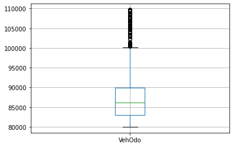

```python
df1.boxplot(column='VehOdo')
```

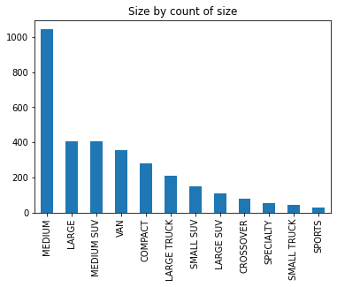

```python
df1.Size.value_counts().plot(kind='bar',title='Size by count of size')
```

The bar plot above filters the data frame by the number of different sizes of vehicles.

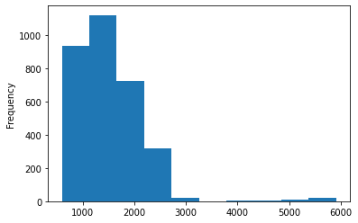

```python
df1['WarrantyCost'].plot.hist(bins=10)
```

The histogram above displays the frequency of a value, in this case, the Warranty Cost column. We interpret that the most frequenct cost is around 1500.

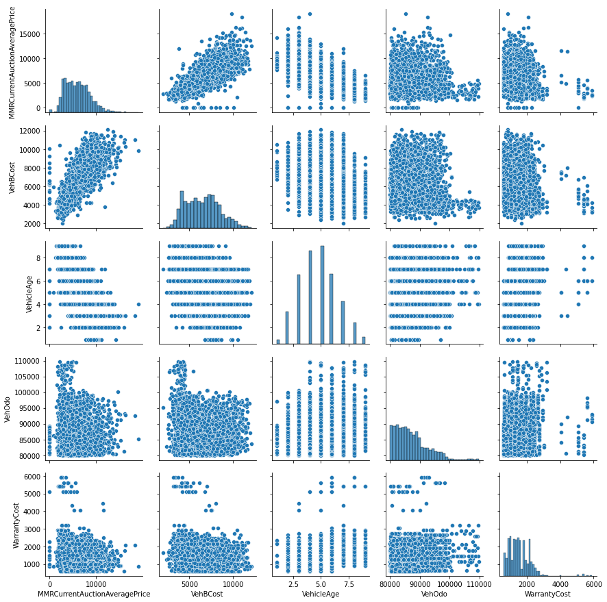

```python
sns.pairplot(df1[['Auction', 'Color', 'IsBadBuy', 'MMRCurrentAuctionAveragePrice', 'Size',
       'TopThreeAmericanName', 'VehBCost', 'VehicleAge', 'VehOdo',
       'WarrantyCost', 'WheelType']])
```

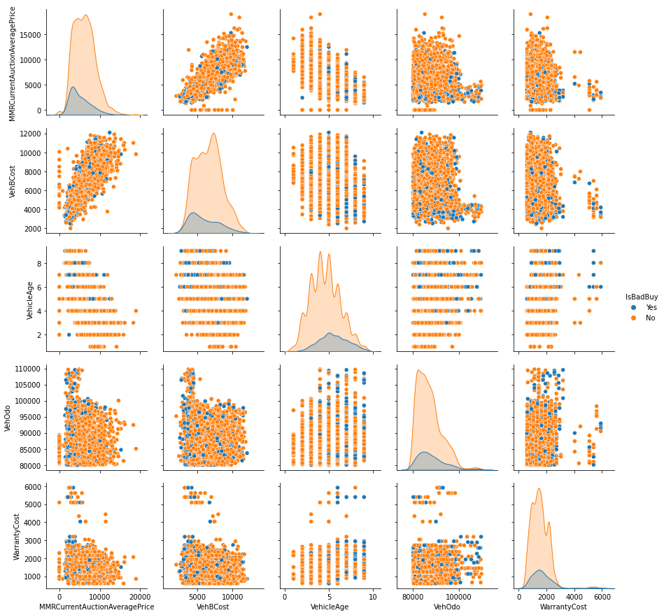

```python
sns.pairplot(df1[['Auction', 'Color', 'IsBadBuy', 'MMRCurrentAuctionAveragePrice', 'Size',
       'TopThreeAmericanName', 'VehBCost', 'VehicleAge', 'VehOdo',
       'WarrantyCost', 'WheelType']],hue='IsBadBuy')
```

By adding the parameter hue='IsBadBuy' helps tremendously to see which aspects are bad buys or not. We see on the legend that orange colored graphs are not bad buys, and blue are bad buys.